# Misagh Mohaghegh - 810199484

Artificial Intelligence CA5: *Machine Learning*  
In this assignment, we will train different classifiers on a dataset and test our models.

## Part 1. Exploratory Data Analysis

### 1.1. Info and Describe

First we will read the data:  
(A column is renamed because the name was too long)

```python
import pandas

diabetes_df = pandas.read_csv('Dataset/diabetes.csv')
diabetes_df.rename(columns={'DiabetesPedigreeFunction':'DiabetesPedigree'}, inplace=True)
```

And run the two methods to get an overall grasp of the data:

```python
diabetes_df.info()
```

```
<class 'pandas.core.frame.DataFrame'>
RangeIndex: 768 entries, 0 to 767
Data columns (total 9 columns):
 #   Column            Non-Null Count  Dtype
---  ------            --------------  -----
 0   Pregnancies       635 non-null    float64
 1   Glucose           654 non-null    float64
 2   BloodPressure     680 non-null    float64
 3   SkinThickness     624 non-null    float64
 4   Insulin           680 non-null    float64
 5   BMI               684 non-null    float64
 6   DiabetesPedigree  590 non-null    float64
 7   Age               655 non-null    float64
 8   Outcome           768 non-null    int64
dtypes: float64(8), int64(1)
memory usage: 54.1 KB
```

The `info` method returns general info about the dataframe, its data, and the data types.

The dataframe's Python class is printed and we can see that there are 768 entries in the dataframe.  
There are 9 columns and for each of them, the column's name, its data types, and the non-null count is shown.  
Non-null count shows how many rows have a value in a specific column.  
At the end, the count of each data type among the columns and the structure's memory usage is shown.

```python
diabetes_df.describe()
```

|  | Pregnancies | Glucose | BloodPressure | SkinThickness | Insulin | BMI | DiabetesPedigree | Age | Outcome |
| --- | --- | --- | --- | --- | --- | --- | --- | --- | --- |
| count | 635.000000 | 654.000000 | 680.000000 | 624.000000 | 680.000000 | 684.000000 | 590.000000 | 655.000000 | 768.000000 |
| mean | 3.700787 | 113.422018 | 68.786765 | 20.386218 | 80.123529 | 32.083626 | 0.466676 | 33.157252 | 0.348958 |
| std | 3.518126 | 202.816831 | 19.724841 | 15.987049 | 115.681140 | 7.800741 | 0.322408 | 13.829831 | 0.476951 |
| min | -22.000000 | -5000.000000 | -2.000000 | 0.000000 | 0.000000 | 0.000000 | 0.078000 | -150.000000 | 0.000000 |
| 25% | 1.000000 | 99.000000 | 62.000000 | 0.000000 | 0.000000 | 27.375000 | 0.243250 | 24.000000 | 0.000000 |
| 50% | 3.000000 | 117.000000 | 72.000000 | 23.000000 | 34.000000 | 32.300000 | 0.368000 | 29.000000 | 0.000000 |
| 75% | 6.000000 | 140.750000 | 80.000000 | 32.000000 | 129.250000 | 36.600000 | 0.611500 | 41.000000 | 1.000000 |
| max | 17.000000 | 199.000000 | 122.000000 | 99.000000 | 846.000000 | 67.100000 | 2.329000 | 81.000000 | 1.000000 |

The `describe` method shows some statistical information about the dataframe.

Each table row reports a property of the corresponding column's data:

- count: The number of the data.
- mean: The average of the data.
- std: The standard deviation of the data.
- min: The minimum data.
- 25%: The first quartile of the column's data.
- 50%: The median of the column's data.
- 75%: The third quartile of the column's data.
- max: The maximum data.

### 1.2. Missing Values

The count and percentage of missing/NaN values in each column:

```python
def missing_values(df: pandas.DataFrame) -> pandas.DataFrame:
    nan_values_count = df.isna().sum()
    nan_values_percent = nan_values_count / len(df)
    nan_values = pandas.concat([nan_values_count, nan_values_percent], axis=1, keys=['Missing', 'Percent'])
    return nan_values.sort_values(by='Missing', ascending=False)

missing_values(diabetes_df)
```

|  | Missing | Percent |
| --- | --- | --- |
| DiabetesPedigree | 178 | 0.231771 |
| SkinThickness | 144 | 0.187500 |
| Pregnancies | 133 | 0.173177 |
| Glucose | 114 | 0.148438 |
| Age | 113 | 0.147135 |
| BloodPressure | 88 | 0.114583 |
| Insulin | 88 | 0.114583 |
| BMI | 84 | 0.109375 |
| Outcome | 0 | 0.000000 |

### 1.3. Correlation Diagram

The correlation heap map is drawn:

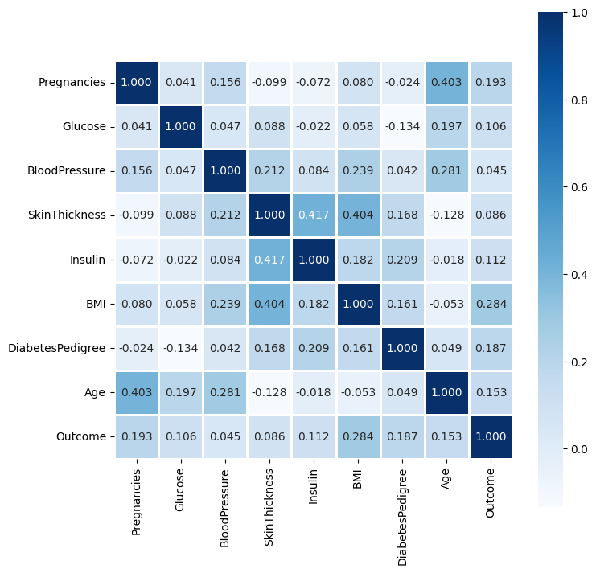

```python
import matplotlib.pyplot as plt
import seaborn

plt.figure(figsize=(8, 8))
seaborn.heatmap(diabetes_df.corr(), annot=True, fmt=".3f", cmap="Blues", linewidths=1, square=True)
plt.show()
```

```python
outcome_corr = diabetes_df.corr()['Outcome'].drop('Outcome')
outcome_corr = outcome_corr[outcome_corr > 0.15].sort_values(ascending=False)
display(outcome_corr)
```

```
BMI                 0.284374
Pregnancies         0.193306
DiabetesPedigree    0.186958
Age                 0.152902
Name: Outcome, dtype: float64
```

As we can see, BMI has the most correlation with the outcome.

### 1.4. Unique Observations of Outcome Correlating Features

Diagrams plotting the count of each unique element of the chosen features in the previous part are shown:

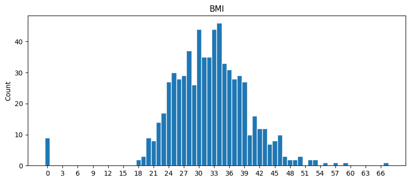

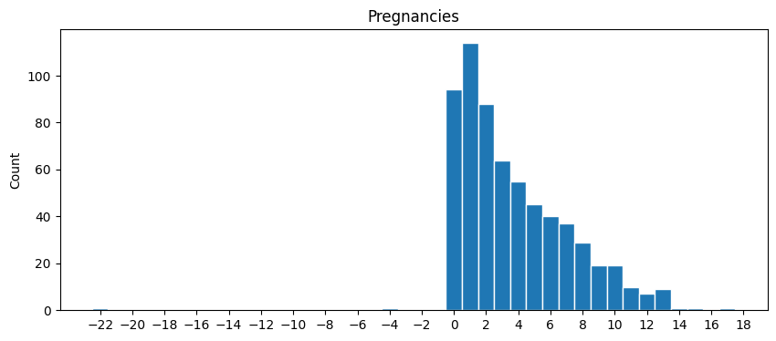

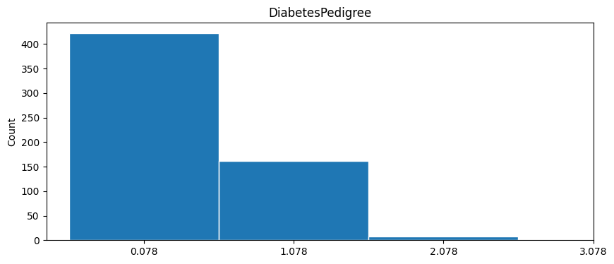

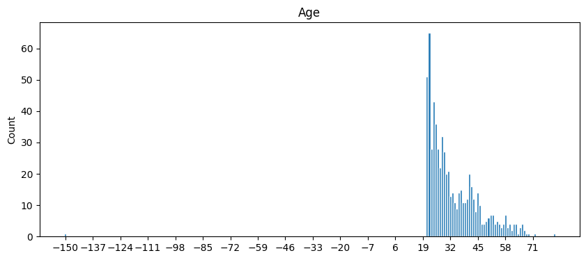

```python
import numpy

for feature in outcome_corr.index:
    data = diabetes_df[feature]
    bins = numpy.arange(data.min(), data.max() + 1.5) - 0.5
    ticks = int((data.max() - data.min()) / 17)
    ticks = 1 if ticks == 0 else ticks
    plt.figure(figsize=(10, 4))
    plt.hist(data, bins, edgecolor='white')
    plt.xticks(bins[::ticks] + 0.5)
    plt.ylabel('Count')
    plt.title(feature)
    plt.show()
```

### 1.5. Visualizing Feature Correlation

Previously, we have chosen some features which have had the highest correlation with our target `Outcome`.  
Here, the scatter and hexbin diagrams are drawn for the chosen features.  
Since the `Outcome` column values are all 0-1, the plots will also only have values when the outcome is 0 or 1.

Using the hexbin diagram, we can also see the density of similar data.  
For example, in the `Age` diagram, we can see that there is a lot of data with age being near 20 and not having diabetes but there also exists some which do have diabetes.

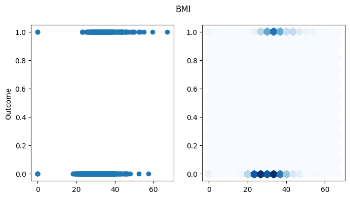

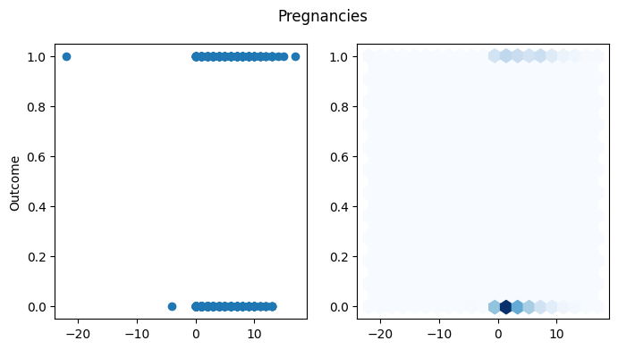

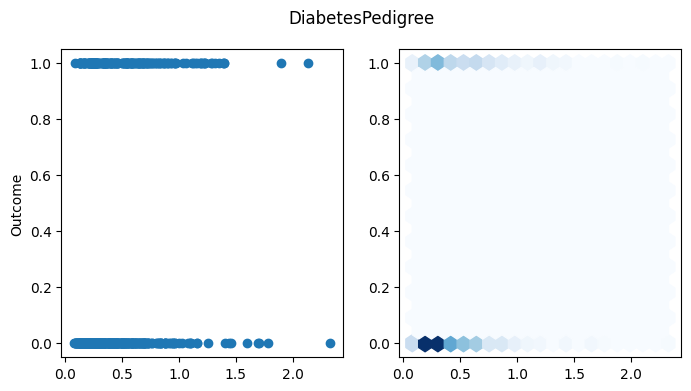

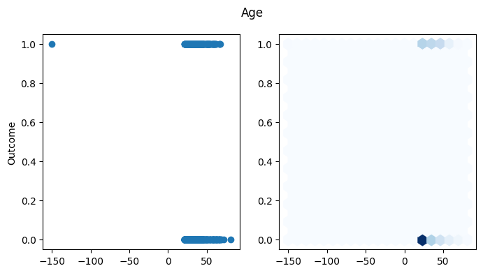

```python
def plot_corr_scatter_hexbin(col):
    plt.figure(figsize=(8, 4))
    plt.suptitle(col)
    plt.subplot(1, 2, 1)
    plt.scatter(diabetes_df[col], diabetes_df['Outcome'])
    plt.ylabel('Outcome')
    plt.subplot(1, 2, 2)
    plt.hexbin(diabetes_df[col], diabetes_df['Outcome'], gridsize=20, cmap='Blues')
    plt.show()

for feature in outcome_corr.index:
    plot_corr_scatter_hexbin(feature)
```

## Part 2. Preprocessing

### 2.0. Out of Bounds

As we have noticed in Part 1, there are some out of bound data that should be removed such as negative age.

```python
diabetes_df[diabetes_df < 0] = numpy.nan
for column in diabetes_df.columns.difference(('Pregnancies', 'DiabetesPedigree', 'Outcome')):
    diabetes_df[column].replace(0, numpy.nan, inplace=True)
```

### 2.1. Missing Values

There are many ways to handle missing values.

- **Dropping**:
  - *Dropping Columns:*  
    In this method we remove any column that has missing values in it.  
    This is usually not wanted because we potentially losing a lot of data.  
    This method should only be considered on columns that have too many missing values; and in fact, its actually the better thing to do in such cases because there is not much data to fill it with good precision.
  - *Dropping Rows:*  
    Works similarly to dropping columns.  
    If we remove all rows that have missing values, if a column is all missing, then all of the rows will be gone.  
    This method should also only be considered on rows that have most of their properties missing.
- **Imputation:**  
  Imputation is the process of replacing missing values with a substitution.
  - *Filling with Mean:*  
    Using the average to fill missing values is simple to do and the mean is a good representative of the data as a whole.  
    But sometimes it may not make sense and be impossible to use for a column.
  - *Filling with Median:*  
    The outlier data can affect the mean negatively.  
    In such cases, it may be better to use the median which is not affected by outliers.
  - *Filling with Mode:*  
    Mean and median do not work with categorical data.  
    Using the mode can be a alternative for such data.
  - *Random Fill:*  
    In this method we fill using random values, mostly in the range of the column's minimum and maximum data, or between the categories.
  - *Predicting:*  
    A more advanced method is to have a way of predicting what the missing value should be based on the other properties of the row.

### 2.2. Handling Missing Values

First of all, we will check the amount of missing values (just as **1.2**) after the preprocessing done in **2.0**:

```python
missing_values(diabetes_df)
```

|  | Missing | Percent |
| --- | --- | --- |
| Insulin | 417 | 0.542969 |
| SkinThickness | 330 | 0.429688 |
| DiabetesPedigree | 178 | 0.231771 |
| Pregnancies | 135 | 0.175781 |
| BloodPressure | 121 | 0.157552 |
| Glucose | 119 | 0.154948 |
| Age | 114 | 0.148438 |
| BMI | 93 | 0.121094 |
| Outcome | 0 | 0.000000 |

As shown, more than 40 percent of the `SkinThickness` and `Insulin` column are missing, and are therefore better to be removed.  
The rest are all numerical and can be filled with the column's median.  
This is to not get affected by outliers and also not be fractional.

```python
diabetes_df.drop(columns=['Insulin', 'SkinThickness'], inplace=True)
diabetes_df.fillna(diabetes_df.median(), inplace=True)
missing_values(diabetes_df)
```

|  | Missing | Percent |
| --- | --- | --- |
| Pregnancies | 0 | 0.0 |
| Glucose | 0 | 0.0 |
| BloodPressure | 0 | 0.0 |
| BMI | 0 | 0.0 |
| DiabetesPedigree | 0 | 0.0 |
| Age | 0 | 0.0 |
| Outcome | 0 | 0.0 |

### 2.3. Normalization and Standardization

These methods are used to scale the data.  
Scaling is changing the range of the values without changing the shape of the distribution.  
This is important for methods that rely on data distance such as KNN.

Standardization assumes a Gaussian distribution in our data and works better if that is the case.  
Normalization is highly affected by outliers and is not a good choice if our data has outliers.

```python
from sklearn.preprocessing import StandardScaler, MinMaxScaler


class DataScaler:
    def __init__(self, dataframe: pandas.DataFrame):
        self.dataframe = dataframe
        self.numeric_cols = dataframe.select_dtypes(include='number')
        self.scaler_std = StandardScaler()
        self.scaler_norm = MinMaxScaler()

    def standard(self, exclude_cols: list = []):
        self.dataframe[self.numeric_cols.columns] = self.scaler_std.fit_transform(self.numeric_cols)
        self.dataframe[exclude_cols] = self.numeric_cols[exclude_cols]

    def normal(self, exclude_cols: list = []):
        self.dataframe[self.numeric_cols.columns] = self.scaler_norm.fit_transform(self.numeric_cols)
        self.dataframe[exclude_cols] = self.numeric_cols[exclude_cols]


scaler = DataScaler(diabetes_df)
scaler.normal(exclude_cols=['Outcome'])
```

### 2.4. Categorical Values

There are many ways to handle categorical columns:

- *Label Encoding:*  
  This is substituting each possible value of a categorical feature with a corresponding number.  
  While label encoding is very simple, it is not always ideal because the numbers do not mean anything and can cause issues if used for calculating distance.  
  This method should not be used for non-ordinal features but works fine with ordinal features.
- *One-Hot Encoding:*  
  In this method, an additional feature is added for each categorical value and is marked 0 or 1.  
  While this encoding is more proper, it adds a lot of new binary features which use more memory and can slow the dataset down.
- *Target Encoding:*  
  This is the process of replacing a categorical value with the mean of a target variable.  
  To do this, the data is grouped by each categorical value, and the average of a chosen target variable is calculated for that group.  
  If the target is numerical, the categorical values are replaced with their corresponding average of the target.  
  If the target is categorical, the values are replaced with their corresponding probability of the target.
- *Frequency Encoding:*  
  In this method, each categorical value is replaced with its frequency in the column.
- *Binary Encoding:*  
  An ordinal encoding (such as label encoding) is applied, then the integers are converted to their binary form.  
  Now the digits from the binary representation are split to separate columns.  
  The result looks similar to one-hot encoding but uses less space.

```python
import category_encoders as cat_enc


class CategoricalEncoder:
    def __init__(self, dataframe: pandas.DataFrame):
        self.dataframe = dataframe
        self.cat_cols = dataframe.select_dtypes(include=['category', 'object'])
        self.label_enc = cat_enc.OrdinalEncoder(cols=self.cat_cols.columns)
        self.onehot_enc = cat_enc.OneHotEncoder(cols=self.cat_cols.columns, use_cat_names=True)
        self.target_enc = cat_enc.TargetEncoder(cols=self.cat_cols.columns, min_samples_leaf=2, smoothing=1.1)
        self.freq_enc = cat_enc.CountEncoder(cols=self.cat_cols.columns)
        self.binary_enc = cat_enc.BinaryEncoder(cols=self.cat_cols.columns)

    def label(self):
        self.dataframe[self.cat_cols.columns] = self.label_enc.fit_transform(self.cat_cols)

    def onehot(self):
        self.dataframe[self.cat_cols.columns] = self.onehot_enc.fit_transform(self.cat_cols)

    def target(self, target: str):
        self.dataframe[self.cat_cols.columns] = self.target_enc.fit_transform(self.cat_cols, self.dataframe[target])

    def freq(self):
        self.dataframe[self.cat_cols.columns] = self.freq_enc.fit_transform(self.cat_cols)

    def binary(self):
        self.dataframe[self.cat_cols.columns] = self.binary_enc.fit_transform(self.cat_cols)


encoder = CategoricalEncoder(diabetes_df)
```

### 2.5. Dropping Columns

As done in **2.2**, the `Insulin` and `SkinThickness` columns were dropped due to having too many missing values.

### 2.6. Test and Train Data

To test a model, we have to first feed and train it with some data, then use some other data to test and see how much it guesses them correctly.

If we have one answer-labeled dataset, we have to split it into two parts: the test and the train data.  
Usually about 3/4 of the data is used for training and the rest is used for testing.  
The common splitting method is to select randomly. Basically to first shuffle the data and then select the first fourth for testing and the rest for training.

Another model validation method is called *cross-validation* which groups the data into *k* parts, and chooses one of them at each iteration and uses it as the test data, while using the rest as training data.  
*K-fold cross-validation* is simply splitting into *k* parts.

```python
from sklearn.model_selection import train_test_split
from dataclasses import dataclass

class DataSplitter:
    def __init__(self, dataframe: pandas.DataFrame, outcome: str, train_percent: float = 0.7):
        self.ddata = dataframe.drop(columns=[outcome])
        self.odata = dataframe[outcome]
        self._split(train_percent)

    def _split(self, train_percent: float):
        split_data = train_test_split(self.ddata, self.odata, train_size=train_percent, random_state=1)
        train_feat, test_feat, train_out, test_out = split_data
        self.dtrain = train_feat
        self.dtest = test_feat
        self.otrain = train_out
        self.otest = test_out

splitter = DataSplitter(diabetes_df, 'Outcome')
```

### 2.7. Validation Data

Validation is another data category that is sometimes used.  
Here, the main dataset is split into three parts: train, validation, and test.  
Their division percentage is about 70-15-15 percent of the data respectively.

The validation data is used to test the trained model before using the testing data.  
During this step, the classifier hyperparameters are adjusted.

## Part 3. Learning and Evaluation

Different classifiers are tested here.  
A class is made for each classifier which can give the accuracy, draw the confusion matrix, and run a grid search for its hyperparameters.  
The hyperparameters are hand-tuned to produce the best test accuracy results.

```python
from sklearn import metrics
from sklearn.tree import DecisionTreeClassifier
from sklearn.neighbors import KNeighborsClassifier
from sklearn.linear_model import LogisticRegression
from sklearn.model_selection import GridSearchCV
```

```python
class DtreeClassifier:
    def __init__(self, split: DataSplitter):
        self.split = split
        self._init()

    def _init(self):
        self.dtree = DecisionTreeClassifier(criterion='entropy', max_depth=8, min_samples_split=8,
                                            min_samples_leaf=2, random_state=1)
        self.dtree.fit(self.split.dtrain, self.split.otrain)
        self.dtree_predict = self.dtree.predict(self.split.dtest)

    def accuracy(self) -> float:
        return metrics.accuracy_score(self.split.otest, self.dtree_predict)

    def accuracy_train(self) -> float:
        train_predict = self.dtree.predict(self.split.dtrain)
        return metrics.accuracy_score(self.split.otrain, train_predict)

    def confusion_matrix(self):
        matrix_dtree = metrics.confusion_matrix(self.split.otest, self.dtree_predict)
        matrix_disp = metrics.ConfusionMatrixDisplay(matrix_dtree)
        matrix_disp.plot(cmap='Blues')
        plt.title('Decision Tree Confusion Matrix')
        plt.show()

    def grid_search(self) -> tuple[float, GridSearchCV]:
        search_params = {
            'criterion': ['entropy'],
            'max_depth': range(4, 12),
            'min_samples_split': range(2, 12),
            'min_samples_leaf': range(1, 10),
            'random_state': [1]
        }
        grid = GridSearchCV(self.dtree, search_params, scoring='accuracy', n_jobs=2)
        grid.fit(self.split.dtrain, self.split.otrain)
        test_score = grid.score(self.split.dtest, self.split.otest)
        return test_score, grid
```

```python
class KnearClassifier:
    def __init__(self, split: DataSplitter, n_neighbors: int = 11):
        self.split = split
        self.n_neighbors = n_neighbors
        self._init()

    def _init(self):
        self.knear = KNeighborsClassifier(n_neighbors=self.n_neighbors)
        self.knear.fit(self.split.dtrain, self.split.otrain)
        self.knear_predict = self.knear.predict(self.split.dtest)

    def accuracy(self) -> float:
        return metrics.accuracy_score(self.split.otest, self.knear_predict)

    def accuracy_train(self) -> float:
        train_predict = self.knear.predict(self.split.dtrain)
        return metrics.accuracy_score(self.split.otrain, train_predict)

    def confusion_matrix(self):
        matrix_knear = metrics.confusion_matrix(self.split.otest, self.knear_predict)
        matrix_disp = metrics.ConfusionMatrixDisplay(matrix_knear)
        matrix_disp.plot(cmap='Blues')
        plt.title('K Nearest Neighbors Confusion Matrix')
        plt.show()

    def grid_search(self) -> tuple[float, GridSearchCV]:
        search_params = {
            'n_neighbors': range(1, 20)
        }
        grid = GridSearchCV(self.knear, search_params, scoring='accuracy', n_jobs=2)
        grid.fit(self.split.dtrain, self.split.otrain)
        test_score = grid.score(self.split.dtest, self.split.otest)
        return test_score, grid
```

```python
class LogregClassifier:
    def __init__(self, split: DataSplitter):
        self.split = split
        self._init()

    def _init(self):
        self.logreg = LogisticRegression(random_state=1)
        self.logreg.fit(self.split.dtrain, self.split.otrain)
        self.logreg_predict = self.logreg.predict(self.split.dtest)

    def accuracy(self) -> float:
        return metrics.accuracy_score(self.split.otest, self.logreg_predict)

    def accuracy_train(self) -> float:
        train_predict = self.logreg.predict(self.split.dtrain)
        return metrics.accuracy_score(self.split.otrain, train_predict)

    def confusion_matrix(self):
        matrix_dtree = metrics.confusion_matrix(self.split.otest, self.logreg_predict)
        matrix_disp = metrics.ConfusionMatrixDisplay(matrix_dtree)
        matrix_disp.plot(cmap='Blues')
        plt.title('Logistic Regression Confusion Matrix')
        plt.show()
```

```python
dtree_clf = DtreeClassifier(splitter)
knear_clf = KnearClassifier(splitter)
logreg_clf = LogregClassifier(splitter)
```

### 3.0. Model Accuracy

```python
print(f'Decision Tree:       {dtree_clf.accuracy() * 100:.3f}%')
print(f'K Nearest Neighbors: {knear_clf.accuracy() * 100:.3f}%')
print(f'Logistic Regression: {logreg_clf.accuracy() * 100:.3f}%')
```

```
Decision Tree:       80.087%
K Nearest Neighbors: 78.355%
Logistic Regression: 77.489%
```

### 3.1. Confusion Matrix

In a confusion matrix, we have the following structure:

|  |  | **Predicted** | **Results** |
| --- | --- | --- | --- |
|  | *Value* | *0* | *1* |
| **Actual** | *0* | TN | FP |
| **Results** | *1* | FN | TP |

- **TN** *(True Negative):* The actual result is false, and the model correctly predicted it as false.
- **FP** *(False Positive):* The actual result is false, but the model wrongly predicted it as true.
- **FN** *(False Negative):* The actual result is true, but the model wrongly predicted it as false.
- **TP** *(True Positive):* The actual result is true, and the model correctly predicted it as true.

Some of the metrics used to assess the prediction results are as follow:

$$ Accuracy = \frac{TP + TN}{TP + TN + FP + FN} $$$$ Precision = \frac{TP}{TP + FP},\, Recall = \frac{TP}{TP + FN} $$

Here we focus on accuracy and show that it matches with the results of **3.0**:

- *Decision Tree:* $ \frac{60 + 125}{60 + 125 + 21 + 25} = 0.80086 \longrightarrow 80.086\% $
- *K Nearest Neighbors:* $ \frac{49 + 132}{49 + 132 + 14 + 36} = 0.78355 \longrightarrow 78.355\% $
- *Logistic Regression:* $ \frac{45 + 134}{45 + 134 + 12 + 40} = 0.77489 \longrightarrow 77.489\% $

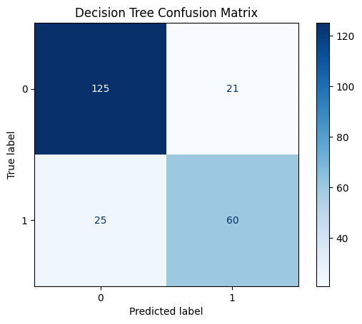

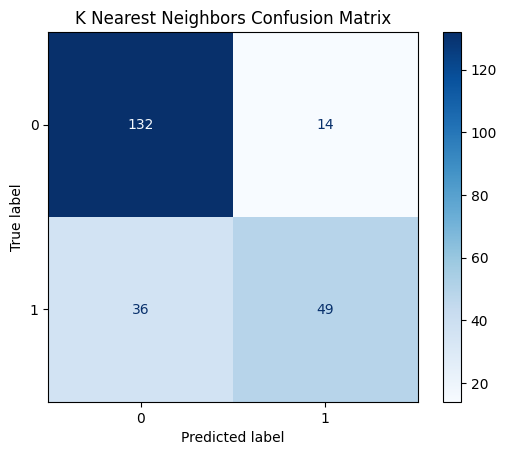

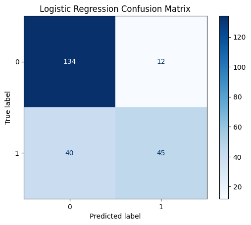

```python
dtree_clf.confusion_matrix()
knear_clf.confusion_matrix()
logreg_clf.confusion_matrix()
```

### 3.2. GridSearchCV

`GridSearchCV` searches all possibilities within the given search parameters and chooses the one which yields the highest results.  
The GridSearch is fit on the training data, and evaluates on itself.  
Basically, it splits the training data to use a part of it for testing; similar idea to validation data explained in **2.7**.

The classifiers' `grid_search` method scores the grid search results on the testing data and returns it along with the chosen parameters.

```python
grid_res = dtree_clf.grid_search()
print(f'Decision Tree\nTest Score: {grid_res[0]}\nParams: {grid_res[1].best_params_}\n')

grid_res = knear_clf.grid_search()
print(f'K Nearest Neighbors\nTest Score: {grid_res[0]}\nParams: {grid_res[1].best_params_}\n')
```

```
Decision Tree
Test Score: 0.7662337662337663
Params: {'criterion': 'entropy', 'max_depth': 6, 'min_samples_leaf': 6, 'min_samples_split': 2, 'random_state': 1}

K Nearest Neighbors
Test Score: 0.7489177489177489
Params: {'n_neighbors': 7}
```

### 3.3. Underfitting and Overfitting

First, we need to explain bias and variance:

- **Bias:**  
  Bias is how precise we are at training the subtleties of the training data.  
  The more precise we are, the lower the bias.  
  This means that we are taking every feature and perhaps the noisy data into account.  
  The lower the bias, the lower our detection error is on the training data.  
  This is not necessarily good because we train on the wrong and noisy data which will lower the generalization of the classifier.
- **Variance:**  
  Variance is a measure of how good the classifier is on unseen data.  
  The better it is on testing data, the lower the variance.  
  This means that the classifier is generalized enough and can detect the testing data correctly.

As much as we want low bias and variance at once, that is not usually the case because once we lower one, the other one increases.  
This is called the *bias-variance tradeoff*.

Now to explain over and underfitting:

- **Overfitting:**  
  This happens when the variance is high and the bias is low.  
  This means that the model works well on the training data but not on the testing data.
- **Underfitting:**  
  This happens when the bias is high and the variance is low.  
  This means that the model does not work well even on the training data.  
  The variance is low which means its very generalized. But this does not necessarily mean that it works well on testing data.

Now we will check if such cases have happened in our classifiers:

```python
print(f'Decision Tree:       {dtree_clf.accuracy_train() * 100:.3f}%')
print(f'K Nearest Neighbors: {knear_clf.accuracy_train() * 100:.3f}%')
print(f'Logistic Regression: {logreg_clf.accuracy_train() * 100:.3f}%')
```

```
Decision Tree:       85.475%
K Nearest Neighbors: 77.654%
Logistic Regression: 75.791%
```

### 3.4. The Effects of Preprocessing

Preprocessing is an extremely important step in machine learning.  
The preprocessing steps have been changed a lot to reach the percentages seen before.  
An example change being the removal of the `SkinThickness` column besides `Insulin`.

## Part 4. Ensemble Learning

```python
from sklearn.ensemble import RandomForestClassifier


class RandForestClassifier:
    def __init__(self, split: DataSplitter, n_estimators: int = 100, max_depth: int = 8):
        self.split = split
        self.n_estimators = n_estimators
        self.max_depth = max_depth
        self._init()

    def _init(self):
        self.randf = RandomForestClassifier(criterion='entropy',
                                            max_depth=self.max_depth,
                                            n_estimators=self.n_estimators,
                                            random_state=1)
        self.randf.fit(self.split.dtrain, self.split.otrain)
        self.randf_predict = self.randf.predict(self.split.dtest)

    def accuracy(self) -> float:
        return metrics.accuracy_score(self.split.otest, self.randf_predict)

    def accuracy_train(self) -> float:
        train_predict = self.randf.predict(self.split.dtrain)
        return metrics.accuracy_score(self.split.otrain, train_predict)

    def confusion_matrix(self):
        matrix_randf = metrics.confusion_matrix(self.split.otest, self.randf_predict)
        matrix_disp = metrics.ConfusionMatrixDisplay(matrix_randf)
        matrix_disp.plot(cmap='Blues')
        plt.title('Random Forest Confusion Matrix')
        plt.show()

    def grid_search(self) -> tuple[float, GridSearchCV]:
        search_params = {
            'n_estimators': range(70, 230, 30),
            'criterion': ['entropy'],
            'max_depth': range(4, 10),
            'random_state': [1]
        }
        grid = GridSearchCV(self.randf, search_params, scoring='accuracy', n_jobs=2)
        grid.fit(self.split.dtrain, self.split.otrain)
        test_score = grid.score(self.split.dtest, self.split.otest)
        return test_score, grid
```

```
Random Forest: 76.623%
```

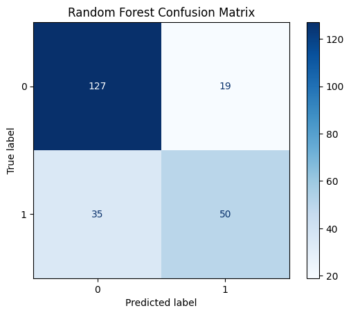

```
Random Forest
Test Score: 0.7835497835497836
Params: {'criterion': 'entropy', 'max_depth': 7, 'n_estimators': 70, 'random_state': 1}
```

```python
randf_clf = RandForestClassifier(splitter)

print(f'Random Forest: {randf_clf.accuracy() * 100:.3f}%')
randf_clf.confusion_matrix()

grid_res = randf_clf.grid_search()
print(f'Random Forest\nTest Score: {grid_res[0]}\nParams: {grid_res[1].best_params_}')
```

### 4.1. Hyperparameters

Some of the hyperparameters for the random forest classifier include:

- `n_estimators`: This is the number of decision trees.
- `criterion`: The means of assessing the quality of a split. `'entropy'` is the information gain method.
- `max_depth`: This is the maximum depth of the decision trees.

Most of the `DecisionTreeClassifier` hyperparameters can also be applied here.

We will now plot 2 of the hyperparameters: n_estimators and max_depth.

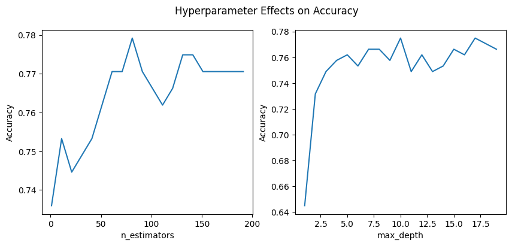

```python
def n_estimators_effects():
    n_estimators = range(1, 200, 10)
    res = []
    for est_count in n_estimators:
        randf = RandForestClassifier(splitter, n_estimators=est_count)
        res.append(randf.accuracy())

    plt.plot(n_estimators, res)
    plt.xlabel('n_estimators')
    plt.ylabel('Accuracy')


def max_depth_effects():
    max_depths = range(1, 20)
    res = []
    for depth in max_depths:
        randf = RandForestClassifier(splitter, max_depth=depth)
        res.append(randf.accuracy())

    plt.plot(max_depths, res)
    plt.xlabel('max_depth')
    plt.ylabel('Accuracy')


plt.figure(figsize=(10, 4))
plt.suptitle('Hyperparameter Effects on Accuracy')
plt.subplot(1, 2, 1)
n_estimators_effects()
plt.subplot(1, 2, 2)
max_depth_effects()
```

Increasing the number of trees help cover more feature combinations for the trees in the forest. Since we get the majority vote of the tree results, the more trees we have, the better our result can be.  
Increasing the max depth of each tree can also help because we get closer to the low biased result.

### 4.2. Versus Decision Tree

Bias and variance are explained in **3.3**.

A decision tree will usually have low bias and is sensitive to the subtle details of the training data. This lowers the generalization power and increases variance.  
A random forest is a form of bagging. It is an ensemble of decision trees that takes majority vote between trees of different features.  
This is designed to correct decision trees' overfitting problems.

```python
from mlxtend.evaluate import bias_variance_decomp


_, dtree_bias, dtree_var = bias_variance_decomp(dtree_clf.dtree,
                                                splitter.dtrain.values, splitter.otrain.values,
                                                splitter.dtest.values, splitter.otest.values,
                                                loss='mse', random_seed=1)
_, randf_bias, randf_var = bias_variance_decomp(randf_clf.randf,
                                                splitter.dtrain.values, splitter.otrain.values,
                                                splitter.dtest.values, splitter.otest.values,
                                                loss='mse', random_seed=1)

print(f'Decision Tree Bias:     {dtree_bias:.3f}')
print(f'Decision Tree Variance: {dtree_var:.3f}')
print(f'Random Forest Bias:     {randf_bias:.3f}')
print(f'Random Forest Variance: {randf_var:.3f}')
```

```
Decision Tree Bias:     0.156
Decision Tree Variance: 0.130
Random Forest Bias:     0.182
Random Forest Variance: 0.059
```

The above calculations show how decision tree has a lower bias and is more overfitted, while random forest has lower variance and is more generalized.